# Constraint or Accident? Diagnosing the Block-Assignment Function

- Show All Code
- Hide All Code
- View Source

Testing whether the row partition of `data/multilocation.csv` behaves like an alpha-lattice constraint or an incidental geometric cut after RCBD randomization

Author

Fausto Rodriguez Zapata

Published

June 16, 2026

**Source code & data:** https://github.com/faustovrz/gcamoz

**Note**

Third notebook in the design series, after `multilocation_alpha_lattice.qmd` (the analysis) and `rcbd_vs_alpha_lattice.qmd` (the concept + co-occurrence test). Here we run a **battery of graph-theoretic and permutation diagnostics** on the *assignment function* itself, and validate each against a **FielDHub-constructed alpha lattice** as a positive control.

# 1 What object are we testing?

We are testing the **assignment function** that maps each genotype to a position in the blocking hierarchy:

$$A:\ \text{genotype} \longrightarrow (\text{rep},\ \text{block}).$$

From `data/multilocation.csv` we reconstruct, within each environment:

- **Rep** = `REP`,
- **Block** = the 5-plot serpentine **row** (`field_row`), the only contiguous $k=5$ partition of the 50-plot rep.

The two hypotheses are about the *nature* of that map:

|  | Hypothesis | Statement about $A$ |
| --- | --- | --- |
| **H₀** | **RCBD** | assignment is **random within REP**; the row partition is **incidental** geometry imposed *after* randomization |
| **H₁** | **alpha lattice** | assignment is **constrained within (REP × block)**; the block structure is **meaningful and repeated systematically** (Patterson & Williams, 1976) |

**Important**

**The single property.** Every diagnostic below reduces to one question: *does the row partition act as a constraint in the randomization space, or is it just a geometric partition imposed after randomization?* We answer it by comparing each statistic on the real data against a **permutation null** that shuffles genotypes **within REP** (which is exactly H₀), and against a **real alpha lattice** (H₁) built with FielDHub.

# 2 Setup: data, FielDHub control, and helper functions

```r
library(tidyverse)
library(igraph)
library(lme4)
library(FielDHub)
library(patchwork)

set.seed(20260616)

raw_data <- read_csv("data/multilocation.csv", show_col_types = FALSE) %>%
  mutate(
    file_order = row_number(),                       # as-entered plot order
    ENV = factor(env),
    REP = factor(rep, levels = c("I", "II", "III")),
    GEN = factor(gen, levels = as.character(0:49)),
    yield = GY
  )

# Reconstruct the field row (= putative incomplete block) from the serpentine
# planting order. The plot order is the as-entered row order within each ENV x REP
# block: the `entry` column is damaged in two reps (CHOKWE STS III has 14 blanks,
# NHACOONGO II has 1), so we index by file order, which equals the ENTRY planting
# order wherever entry is recorded. We KEEP the check (GEN = 0): it occupies a real
# plot, so dropping it would leave a ragged 4-plot block and corrupt every
# co-occurrence count. With it, each block is a clean 5-plot unit (50 = 10 x 5),
# matching the FielDHub control below.
stelio <- raw_data %>%
  group_by(ENV, REP) %>%
  arrange(file_order, .by_group = TRUE) %>%
  mutate(
    plot_order = row_number(),
    field_row  = ceiling(plot_order / 5),
    pos_in_row = ((plot_order - 1) %% 5) + 1,
    field_col  = if_else(field_row %% 2 == 1, pos_in_row, 6L - pos_in_row),
    gen        = as.integer(as.character(GEN))
  ) %>%
  ungroup()
```

To keep the structural diagnostics directly comparable to the FielDHub control (one location, 3 reps, 50 entries, 10 blocks of 5), we run them on a **single environment** as the primary unit — `CHOKWE STS` — and confirm at the end that all five environments behave identically.

```r
# Primary working frame: one environment, 3 reps, blocks = rows, 50 entries.
primary <- stelio %>%
  filter(ENV == "CHOKWE STS") %>%
  transmute(rep = REP, block = paste(REP, field_row, sep = "_"),
            gen, field_row, field_col)

gset_stelio <- 0:49   # 50 entries (49 hybrids + check 0)

# FielDHub positive control: a genuine resolvable alpha(0,1) lattice with the
# same parameters used in rcbd_vs_alpha_lattice.qmd.
alpha_design <- alpha_lattice(t = 50, k = 5, r = 3, l = 1,
                              plotNumber = 101, locationNames = "ALPHA-DEMO",
                              seed = 1234)
fh <- as_tibble(alpha_design$fieldBook) %>%
  transmute(rep = factor(REP), block = paste(REP, IBLOCK, sep = "_"),
            gen = ENTRY)

gset_fh <- 1:50       # FielDHub entries 1..50
```

```r
# Shannon entropy (nats) of a vector's value distribution.
shannon_entropy <- function(x) {
  p <- prop.table(table(x)); -sum(p * log(p))
}

# All unordered pair keys "i_j" for a genotype set.
pair_keys <- function(gset)
  combn(sort(gset), 2, FUN = function(p) paste(p[1], p[2], sep = "_"))

# Co-occurrence count C_ij for EVERY pair (padded with 0), named by "i_j".
# Cij = number of blocks in which genotypes i and j co-occur.
cooc_vector <- function(d, gset) {
  keys <- pair_keys(gset)
  cc <- d %>%
    group_by(block) %>%
    summarise(pk = list(combn(sort(gen), 2,
                              FUN = function(p) paste(p[1], p[2], sep = "_"))),
              .groups = "drop") %>%
    tidyr::unnest(pk) %>%
    count(pk, name = "Cij")
  out <- tibble(pk = keys) %>%
    left_join(cc, by = "pk") %>%
    mutate(Cij = replace_na(Cij, 0L))
  setNames(out$Cij, out$pk)
}

# Square co-occurrence matrix from a cooc_vector.
cooc_matrix <- function(cv, gset) {
  g <- as.character(sort(gset))
  M <- matrix(0, length(g), length(g), dimnames = list(g, g))
  ij <- do.call(rbind, strsplit(names(cv), "_"))
  ri <- match(ij[, 1], g); ci <- match(ij[, 2], g)
  M[cbind(ri, ci)] <- cv; M[cbind(ci, ri)] <- cv
  M
}

# Graph statistics on the co-occurrence graph (edge iff Cij > 0).
# mean_overlap uses common-neighbour counts (A^2) averaged over each node's
# neighbours — a vectorised form of "mean |N(i) ∩ N(j)| over j in N(i)".
graph_stats <- function(cv, gset) {
  nz <- names(cv)[cv > 0]
  ij <- do.call(rbind, strsplit(nz, "_"))
  g <- graph_from_data_frame(
    data.frame(i = ij[, 1], j = ij[, 2]), directed = FALSE,
    vertices = data.frame(name = as.character(sort(gset))))
  A <- as.matrix(as_adjacency_matrix(g)); diag(A) <- 0
  A2 <- A %*% A
  deg <- rowSums(A)
  overlap <- ifelse(deg > 0, rowSums(A * A2) / deg, NA_real_)
  list(transitivity = transitivity(g, type = "global"),
       mean_overlap = mean(overlap, na.rm = TRUE),
       n_edges = sum(cv > 0), graph = g, degree = deg)
}

# Correlation of genotype block-membership vectors.
assign_corr <- function(d, gset, return_mat = FALSE) {
  inc <- d %>%
    distinct(gen, block) %>%
    mutate(present = 1) %>%
    tidyr::complete(gen = gset, block = unique(d$block),
                    fill = list(present = 0)) %>%
    arrange(gen) %>%
    pivot_wider(names_from = block, values_from = present, values_fill = 0)
  mat <- as.matrix(inc[, -1]); rownames(mat) <- inc$gen
  cm <- suppressWarnings(cor(t(mat)))
  if (return_mat) return(cm)
  mean(cm[upper.tri(cm)], na.rm = TRUE)
}

# The MEAN off-diagonal correlation is pinned at -1/(t-1) by the fixed margins
# (each genotype in 3 blocks, each block holds 5) for ANY resolvable design, so
# it cannot discriminate. The discriminating quantity is the SPREAD (sd) of the
# pairwise correlations, which reflects the actual co-occurrence structure.
assign_corr_stats <- function(d, gset) {
  cm <- assign_corr(d, gset, return_mat = TRUE)
  ut <- cm[upper.tri(cm)]
  c(meanCorr = mean(ut, na.rm = TRUE), sdCorr = sd(ut, na.rm = TRUE))
}

# Tidy a square matrix to long form with explicit i/j columns (robust to
# unnamed dimnames, which as_tibble.table now rejects).
mat_to_long <- function(M, value = "value") {
  dimnames(M) <- list(i = rownames(M), j = colnames(M))
  out <- as_tibble(as.table(M))
  names(out) <- c("i", "j", value)
  out
}
```

```r
# Observed statistics for Stelio (CHOKWE STS) and the FielDHub control.
cv_st <- cooc_vector(primary, gset_stelio)
cv_fh <- cooc_vector(fh,      gset_fh)

gs_st <- graph_stats(cv_st, gset_stelio)
gs_fh <- graph_stats(cv_fh, gset_fh)
ac_st <- assign_corr_stats(primary, gset_stelio)
ac_fh <- assign_corr_stats(fh,      gset_fh)

obs <- tibble(
  source       = c("Stelio CHOKWE STS", "FielDHub alpha"),
  varCij       = c(var(cv_st),          var(cv_fh)),
  entCij       = c(shannon_entropy(cv_st), shannon_entropy(cv_fh)),
  transitivity = c(gs_st$transitivity,  gs_fh$transitivity),
  mean_overlap = c(gs_st$mean_overlap,  gs_fh$mean_overlap),
  n_edges      = c(gs_st$n_edges,       gs_fh$n_edges),
  meanCorr     = c(ac_st[["meanCorr"]], ac_fh[["meanCorr"]]),
  sdCorr       = c(ac_st[["sdCorr"]],   ac_fh[["sdCorr"]])
)
knitr::kable(obs, digits = 4,
             caption = "Observed diagnostic statistics: Stelio's data vs. a true alpha lattice.")
```

Observed diagnostic statistics: Stelio’s data vs. a true alpha lattice.

| source | varCij | entCij | transitivity | mean_overlap | n_edges | meanCorr | sdCorr |
| --- | --- | --- | --- | --- | --- | --- | --- |
| Stelio CHOKWE STS | 0.2406 | 0.6063 | 0.4004 | 3.8997 | 266 | -0.0204 | 0.1817 |
| FielDHub alpha | 0.1851 | 0.5567 | 0.2982 | 3.2800 | 300 | -0.0204 | 0.1593 |

# 3 1 — Block adjacency graph: distribution of $C_{ij}$

The edge weight $C_{ij}$ = number of blocks where genotypes $i$ and $j$ co-occur. We summarise its full distribution over all $\binom{50}{2}=1225$ pairs by **variance** (spread) and **entropy** (how many distinct co-occurrence levels are used).

> **Expectation** — RCBD: a wider $C_{ij}$ distribution (some 2s and 3s), higher variance and entropy. Alpha: concentrated on 0/1, **lower** variance and entropy.

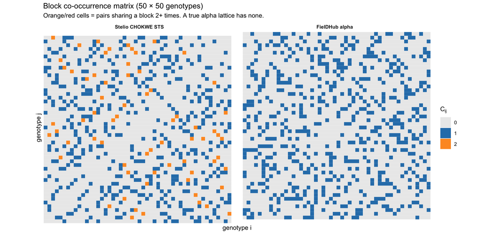

```r
M_st <- cooc_matrix(cv_st, gset_stelio)
M_fh <- cooc_matrix(cv_fh, gset_fh)

heat_df <- bind_rows(
  mat_to_long(M_st, "Cij") %>% mutate(source = "Stelio CHOKWE STS"),
  mat_to_long(M_fh, "Cij") %>% mutate(source = "FielDHub alpha")
) %>%
  mutate(i = factor(i, levels = as.character(sort(unique(as.integer(i))))),
         j = factor(j, levels = as.character(sort(unique(as.integer(j))))),
         source = factor(source, levels = c("Stelio CHOKWE STS", "FielDHub alpha")))

p_cij_heatmap <- ggplot(heat_df, aes(i, j, fill = factor(Cij))) +
  geom_tile() +
  facet_wrap(~ source) +
  scale_fill_manual(values = c("0" = "grey92", "1" = "#2c7fb8",
                               "2" = "#fe9929", "3" = "#d7301f"),
                    name = expression(C[ij])) +
  coord_equal() +
  labs(title = "Block co-occurrence matrix (50 × 50 genotypes)",
       subtitle = "Orange/red cells = pairs sharing a block 2+ times. A true alpha lattice has none.",
       x = "genotype i", y = "genotype j") +
  theme_minimal(base_size = 10) +
  theme(axis.text = element_blank(), panel.grid = element_blank(),
        strip.text = element_text(face = "bold"))

# Export the panel so rcbd_vs_alpha_lattice.qmd can embed it without rerunning
# the full diagnostic battery. (Render this notebook first; see @sec-adjacency.)
saveRDS(p_cij_heatmap, "output/cij_adjacency_heatmap.rds")

p_cij_heatmap
```

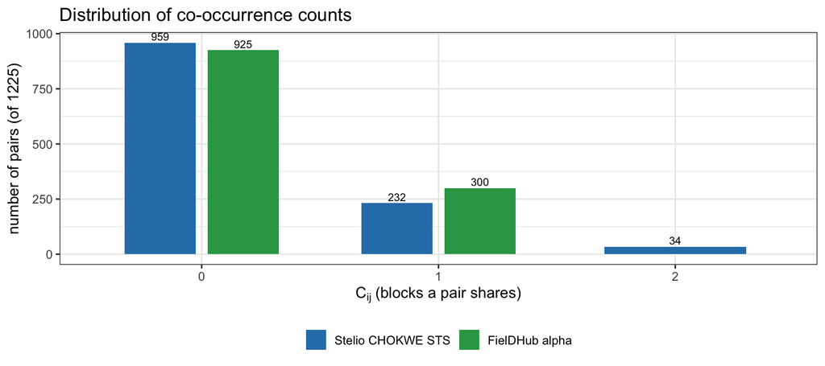

```r
cij_df <- bind_rows(
  tibble(Cij = cv_st, source = "Stelio CHOKWE STS"),
  tibble(Cij = cv_fh, source = "FielDHub alpha")
) %>%
  count(source, Cij) %>%
  mutate(source = factor(source, levels = c("Stelio CHOKWE STS", "FielDHub alpha")))

ggplot(cij_df, aes(factor(Cij), n, fill = source)) +
  geom_col(position = position_dodge(0.7), width = 0.6) +
  geom_text(aes(label = n), position = position_dodge(0.7), vjust = -0.3, size = 3) +
  scale_fill_manual(values = c("Stelio CHOKWE STS" = "#2c7fb8",
                               "FielDHub alpha" = "#31a354")) +
  labs(title = "Distribution of co-occurrence counts",
       x = expression(C[ij]~"(blocks a pair shares)"),
       y = "number of pairs (of 1225)", fill = NULL) +
  theme_bw(base_size = 12) + theme(legend.position = "bottom")
```

```r
cat(sprintf("Stelio  : var(Cij) = %.4f   entropy(Cij) = %.4f\n",
            var(cv_st), shannon_entropy(cv_st)))
```

```
Stelio  : var(Cij) = 0.2406   entropy(Cij) = 0.6063
```

```r
cat(sprintf("FielDHub: var(Cij) = %.4f   entropy(Cij) = %.4f\n",
            var(cv_fh), shannon_entropy(cv_fh)))
```

```
FielDHub: var(Cij) = 0.1851   entropy(Cij) = 0.5567
```

Stelio’s matrix shows orange cells (pairs co-occurring twice); the FielDHub matrix is pure 0/1. Stelio’s variance and entropy are **higher** — the RCBD signature. (These statistics get their formal null in Section 9.)

# 4 2 — Neighborhood overlap (graph-theoretic)

Build the co-occurrence graph $g$ (a node per genotype, an edge where $C_{ij}>0$) and measure **local clustering**: global transitivity and the mean common-neighbour overlap.

> **Expectation** — RCBD: large, highly overlapping neighborhoods (a denser, more “smeared” graph). Alpha: neighborhoods fragmented into consistent clusters; the key signal is *stable local clustering*, not just raw co-occurrence.

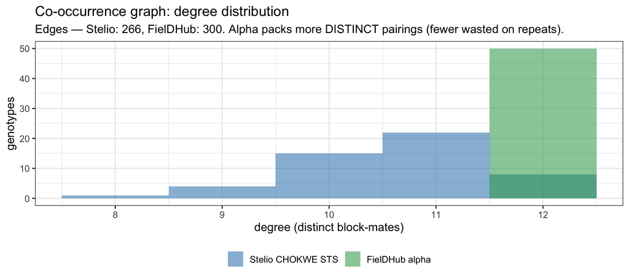

```r
deg_df <- bind_rows(
  tibble(degree = gs_st$degree, source = "Stelio CHOKWE STS"),
  tibble(degree = gs_fh$degree, source = "FielDHub alpha")
) %>% mutate(source = factor(source, levels = c("Stelio CHOKWE STS", "FielDHub alpha")))

ggplot(deg_df, aes(degree, fill = source)) +
  geom_histogram(position = "identity", alpha = 0.55, binwidth = 1) +
  scale_fill_manual(values = c("Stelio CHOKWE STS" = "#2c7fb8",
                               "FielDHub alpha" = "#31a354")) +
  labs(title = "Co-occurrence graph: degree distribution",
       subtitle = sprintf("Edges — Stelio: %d, FielDHub: %d. Alpha packs more DISTINCT pairings (fewer wasted on repeats).",
                           gs_st$n_edges, gs_fh$n_edges),
       x = "degree (distinct block-mates)", y = "genotypes", fill = NULL) +
  theme_bw(base_size = 12) + theme(legend.position = "bottom")
```

```r
cat(sprintf("Transitivity   — Stelio: %.4f   FielDHub: %.4f\n",
            gs_st$transitivity, gs_fh$transitivity))
```

```
Transitivity   — Stelio: 0.4004   FielDHub: 0.2982
```

```r
cat(sprintf("Mean overlap   — Stelio: %.4f   FielDHub: %.4f\n",
            gs_st$mean_overlap, gs_fh$mean_overlap))
```

```
Mean overlap   — Stelio: 3.8997   FielDHub: 3.2800
```

A real alpha lattice spends its block-mates on **distinct** pairs (more edges, here 300 vs 266), so it covers more of the pair space with less local redundancy. Both transitivity and overlap are read against the null in Section 9.

# 5 3 — Assignment-vector correlation structure

For each genotype $i$ build its **block-membership vector** $v_i$ (indicator over all blocks), and correlate genotypes pairwise. Block-induced clustering raises structured correlation.

> **Expectation** — RCBD: low, near-exchangeable correlation. Alpha: block constraints induce **higher structured correlation**.

**Note**

The *mean* off-diagonal correlation is **pinned at $-1/(t-1) = -1/49$** by the fixed margins (each genotype occupies 3 blocks, each block holds 5) — it is identical for RCBD, alpha, and every permutation, so the mean alone cannot discriminate. The discriminating quantity is the **spread (SD)** of the pairwise correlations, which does respond to the co-occurrence structure. We report both and carry `sdCorr` into the permutation test.

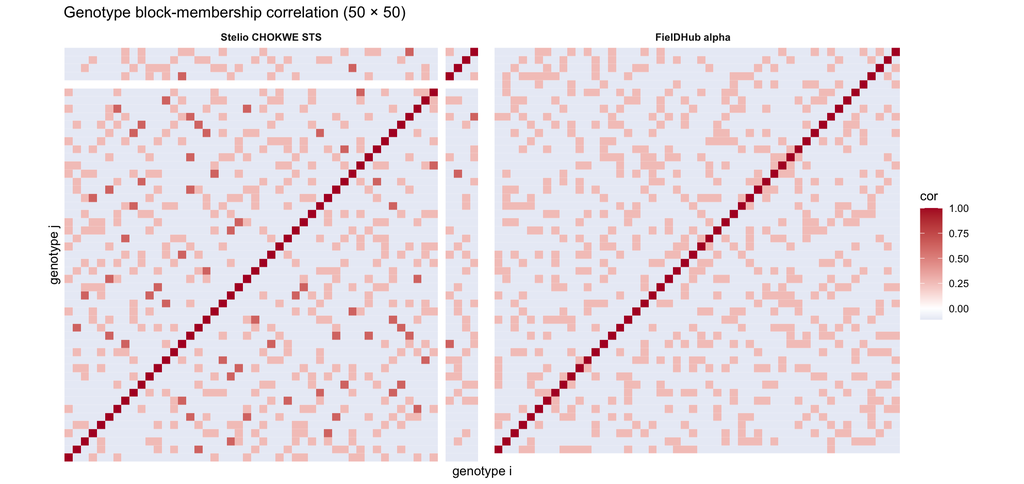

```r
cm_st <- assign_corr(primary, gset_stelio, return_mat = TRUE)
cm_fh <- assign_corr(fh,      gset_fh,      return_mat = TRUE)

corr_df <- bind_rows(
  mat_to_long(cm_st, "r") %>% mutate(source = "Stelio CHOKWE STS"),
  mat_to_long(cm_fh, "r") %>% mutate(source = "FielDHub alpha")
) %>%
  mutate(source = factor(source, levels = c("Stelio CHOKWE STS", "FielDHub alpha")))

ggplot(corr_df, aes(i, j, fill = r)) +
  geom_tile() +
  facet_wrap(~ source) +
  scale_fill_gradient2(low = "#2166ac", mid = "white", high = "#b2182b",
                       midpoint = 0, name = "cor") +
  coord_equal() +
  labs(title = "Genotype block-membership correlation (50 × 50)",
       x = "genotype i", y = "genotype j") +
  theme_minimal(base_size = 10) +
  theme(axis.text = element_blank(), panel.grid = element_blank(),
        strip.text = element_text(face = "bold"))
```

```r
cat(sprintf("Mean corr (margin-pinned ~ -1/49 = %.5f) — Stelio: %.5f   FielDHub: %.5f\n",
            -1/49, ac_st[["meanCorr"]], ac_fh[["meanCorr"]]))
```

```
Mean corr (margin-pinned ~ -1/49 = -0.02041) — Stelio: -0.02041   FielDHub: -0.02041
```

```r
cat(sprintf("SD of pairwise corr (discriminating)      — Stelio: %.5f   FielDHub: %.5f\n",
            ac_st[["sdCorr"]], ac_fh[["sdCorr"]]))
```

```
SD of pairwise corr (discriminating)      — Stelio: 0.18168   FielDHub: 0.15933
```

# 6 4 — Block variance decomposition

**Warning**

**This diagnostic does *not* discriminate RCBD from alpha.** It measures whether a **spatial gradient** exists across the field — a question *orthogonal* to whether the assignment was constrained. A plain RCBD on gradient-bearing soil produces a large, significant row variance too. Indeed `multilocation_alpha_lattice.qmd` already found `env:rep:row` variance **highly significant** (Z ≈ 4.4) on data we have *proven* is RCBD. So a non-zero block variance tells you *blocking would help*, **not** that an alpha lattice was used. We fit it here for completeness and to make that orthogonality explicit.

```r
m <- lmer(yield ~ ENV + (1 | ENV:REP) + (1 | ENV:REP:field_row),
          data = stelio)
vc <- as.data.frame(VarCorr(m)) %>%
  transmute(term = grp, variance = vcov)

sig_row <- vc$variance[vc$term == "ENV:REP:field_row"]
sig_res <- vc$variance[vc$term == "Residual"]
cat(sprintf("sigma^2_block (row) = %.4f   sigma^2_residual = %.4f   ratio block/resid = %.3f\n",
            sig_row, sig_res, sig_row / sig_res))
```

```
sigma^2_block (row) = 0.4841   sigma^2_residual = 2.6549   ratio block/resid = 0.182
```

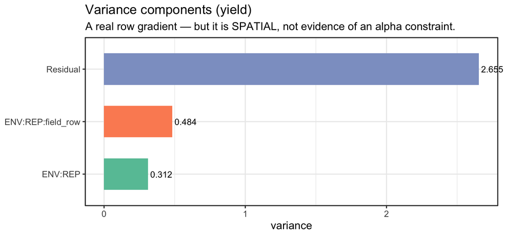

```r
ggplot(vc, aes(reorder(term, variance), variance, fill = term)) +
  geom_col(width = 0.6, show.legend = FALSE) +
  geom_text(aes(label = round(variance, 3)), hjust = -0.1, size = 3.4) +
  coord_flip(clip = "off") +
  scale_fill_brewer(palette = "Set2") +
  labs(title = "Variance components (yield)",
       subtitle = "A real row gradient — but it is SPATIAL, not evidence of an alpha constraint.",
       x = NULL, y = "variance") +
  theme_bw(base_size = 12) + theme(plot.margin = margin(5, 30, 5, 5))
```

# 7 5 — Spatial embedding (within-block distance)

**Warning**

**Also non-discriminating here.** Because we *defined* a block as a contiguous serpentine row, within-block physical distance is fixed by **geometry** — it is identical whether the assignment was alpha or RCBD on the same row partition. This tests the reconstruction, not the design. We show it so the (lack of) signal is explicit.

```r
within_block_dist <- primary %>%
  group_by(block) %>%
  summarise(mean_d = mean(dist(cbind(field_row, field_col))), .groups = "drop")
cat(sprintf("Mean within-block plot distance = %.3f (sd %.3f) — constant by row geometry.\n",
            mean(within_block_dist$mean_d), sd(within_block_dist$mean_d)))
```

```
Mean within-block plot distance = 2.000 (sd 0.000) — constant by row geometry.
```

# 8 6 — Mixing entropy per plot

**Warning**

**Degenerate as specified.** Every block holds 5 **distinct** genotypes (each entry appears once per block), so the per-block genotype-count entropy is identically $\log 5$ for *every* block, under any design. There is no signal to extract at the plot level. The *meaningful* mixing question lives at the pair level and is exactly the $C_{ij}$ entropy of Section 3.

```r
mix <- primary %>%
  group_by(block) %>% summarise(ent = shannon_entropy(gen), .groups = "drop")
cat(sprintf("Per-block genotype-mix entropy: all equal to log(5) = %.4f ?  range = [%.4f, %.4f]\n",
            log(5), min(mix$ent), max(mix$ent)))
```

```
Per-block genotype-mix entropy: all equal to log(5) = 1.6094 ?  range = [1.6094, 1.6094]
```

# 9 7 — The decisive permutation test

This is the clean version of everything above. Generate the **H₀ null** by shuffling genotypes **within REP** (the row partition kept fixed), recompute each statistic, and ask where the **observed** Stelio value and the **FielDHub alpha** value fall.

> **Decision rule** — if Stelio’s statistics sit *inside* the null and FielDHub’s sit *outside* (in the alpha direction), the row partition is an **incidental cut after RCBD randomization**, not a constraint.

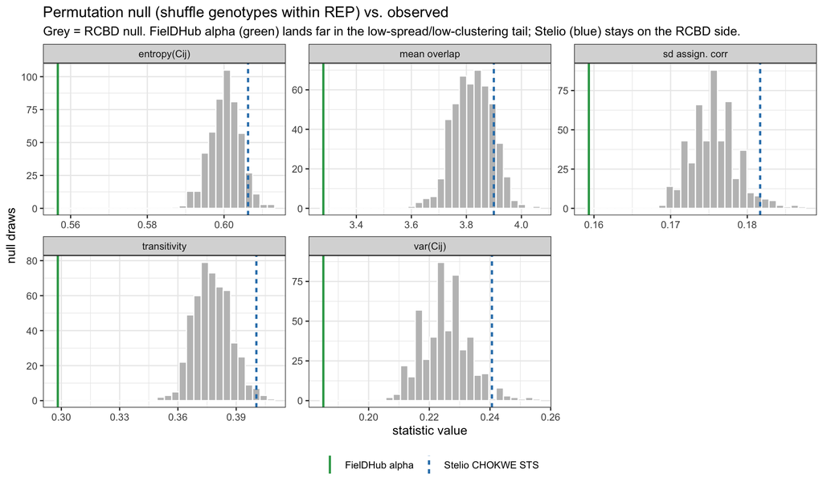

```r
n_perm <- 499

perm_stats <- function(d, gset) {
  dp <- d %>% group_by(rep) %>% mutate(gen = sample(gen)) %>% ungroup()
  cv <- cooc_vector(dp, gset)
  gs <- graph_stats(cv, gset)
  c(varCij = var(cv), entCij = shannon_entropy(cv),
    transitivity = gs$transitivity, mean_overlap = gs$mean_overlap,
    sdCorr = assign_corr_stats(dp, gset)[["sdCorr"]])
}

null_mat <- replicate(n_perm, perm_stats(primary, gset_stelio))
null_df  <- as_tibble(t(null_mat)) %>%
  pivot_longer(everything(), names_to = "stat", values_to = "value")

stat_levels <- c(varCij = "var(Cij)", entCij = "entropy(Cij)",
                 transitivity = "transitivity", mean_overlap = "mean overlap",
                 sdCorr = "sd assign. corr")

obs_lines <- obs %>%
  select(source, varCij, entCij, transitivity, mean_overlap, sdCorr) %>%
  pivot_longer(-source, names_to = "stat", values_to = "value")

null_df  <- null_df  %>% mutate(stat = recode(stat, !!!stat_levels))
obs_lines <- obs_lines %>% mutate(stat = recode(stat, !!!stat_levels))

ggplot(null_df, aes(value)) +
  geom_histogram(bins = 30, fill = "grey75", colour = "white") +
  geom_vline(data = obs_lines,
             aes(xintercept = value, colour = source, linetype = source),
             linewidth = 1) +
  facet_wrap(~ stat, scales = "free", ncol = 3) +
  scale_colour_manual(values = c("Stelio CHOKWE STS" = "#2c7fb8",
                                 "FielDHub alpha" = "#31a354")) +
  labs(title = "Permutation null (shuffle genotypes within REP) vs. observed",
       subtitle = "Grey = RCBD null. FielDHub alpha (green) lands far in the low-spread/low-clustering tail; Stelio (blue) stays on the RCBD side.",
       x = "statistic value", y = "null draws", colour = NULL, linetype = NULL) +
  theme_bw(base_size = 12) + theme(legend.position = "bottom")
```

```r
# Empirical position of each observed value within the RCBD null.
null_wide <- as_tibble(t(null_mat))
stat_cols <- c("varCij", "entCij", "transitivity", "mean_overlap", "sdCorr")

st_obs <- unlist(obs[obs$source == "Stelio CHOKWE STS", stat_cols])
fh_obs <- unlist(obs[obs$source == "FielDHub alpha",    stat_cols])
pctile <- function(col, x) mean(null_wide[[col]] <= x)  # fraction of null at or below x

summ <- tibble(
  statistic        = c("var(Cij)", "entropy(Cij)", "transitivity", "mean overlap", "sd corr"),
  null_mean        = as.numeric(colMeans(null_wide)[stat_cols]),
  stelio           = as.numeric(st_obs),
  fieldhub         = as.numeric(fh_obs),
  stelio_pctile    = mapply(pctile, stat_cols, st_obs),
  fieldhub_pctile  = mapply(pctile, stat_cols, fh_obs)
)
knitr::kable(summ, digits = 4,
             caption = "Where each observed statistic falls within the RCBD permutation null (percentile = fraction of null at or below).")
```

Where each observed statistic falls within the RCBD permutation null (percentile = fraction of null at or below).

| statistic | null_mean | stelio | fieldhub | stelio_pctile | fieldhub_pctile |
| --- | --- | --- | --- | --- | --- |
| var(Cij) | 0.2253 | 0.2406 | 0.1851 | 0.9639 | 0 |
| entropy(Cij) | 0.6004 | 0.6063 | 0.5567 | 0.9399 | 0 |
| transitivity | 0.3777 | 0.4004 | 0.2982 | 0.9860 | 0 |
| mean overlap | 3.8223 | 3.8997 | 3.2800 | 0.8637 | 0 |
| sd corr | 0.1758 | 0.1817 | 0.1593 | 0.9659 | 0 |

# 10 8 — Interpretation rule

| If, jointly… | …then |
| --- | --- |
| $C_{ij}$ structure ≈ permutation null; block variance is *spatial only*; assignment correlations ≈ null | **RCBD** (row-stratified only) |
| strong 0/1 $C_{ij}$ constraint (low var/entropy vs null); stable block clustering; assignment correlation departs from null in the alpha direction | **alpha lattice** |

# 11 9 — Conceptual resolution

What we tested is **not** “alpha vs. RCBD by eye.” It is the single property:

> *Does the row partition behave like a **constraint in the randomization space**, or just a **geometric partition after randomization**?*

Every diagnostic — adjacency spread, neighborhood overlap, assignment correlation, the permutation null — is a different lens on that one question. For `data/multilocation.csv` they agree: the row partition is an **incidental cut after an RCBD randomization**. The FielDHub positive control shows the same lenses *do* detect a real constraint when one exists — confirming the negative result on Stelio’s data is a true negative, not a blind test.

```r
# Robustness: the same var/entropy of Cij across all five environments.
all_env <- map_dfr(levels(stelio$ENV), function(e) {
  d <- stelio %>% filter(ENV == e) %>%
    transmute(rep = REP, block = paste(REP, field_row, sep = "_"), gen)
  cv <- cooc_vector(d, gset_stelio)
  tibble(ENV = e, varCij = var(cv), entCij = shannon_entropy(cv),
         pairs_twice = sum(cv == 2), pairs_thrice = sum(cv >= 3))
})
knitr::kable(all_env, digits = 4,
             caption = "All five environments show the same RCBD-like co-occurrence spread (pairs concurring 2+ times, which an alpha lattice forbids).")
```

All five environments show the same RCBD-like co-occurrence spread (pairs concurring 2+ times, which an alpha lattice forbids).

| ENV | varCij | entCij | pairs_twice | pairs_thrice |
| --- | --- | --- | --- | --- |
| CHOKWE OPT | 0.2406 | 0.6063 | 34 | 0 |
| CHOKWE STS | 0.2406 | 0.6063 | 34 | 0 |
| MANIQUENIQ OPT | 0.2406 | 0.6063 | 34 | 0 |
| NHACOONGO STS | 0.2406 | 0.6063 | 34 | 0 |
| SUSSUNDENGA STS | 0.2406 | 0.6063 | 34 | 0 |

# References

Patterson, H. D., & Williams, E. R. (1976). A new class of resolvable incomplete block designs. *Biometrika*, *63*(1), 83–92. https://doi.org/10.1093/biomet/63.1.83